# Activity monitoring assignment - Anastasye

# Part 1:

## What is mean total number of steps taken per day?

Loading the data:

```r
library(rmarkdown)
activeData <- read.csv("activity.csv", header = TRUE)
```

Total number of steps taken per day:

```r
stepDay <- aggregate(.~date, data=activeData, sum, na.rm=TRUE)
stepDay
```

```
##          date steps interval
## 1  2012-10-02   126   339120
## 2  2012-10-03 11352   339120
## 3  2012-10-04 12116   339120
## 4  2012-10-05 13294   339120
## 5  2012-10-06 15420   339120
## 6  2012-10-07 11015   339120
## 7  2012-10-09 12811   339120
## 8  2012-10-10  9900   339120
## 9  2012-10-11 10304   339120
## 10 2012-10-12 17382   339120
## 11 2012-10-13 12426   339120
## 12 2012-10-14 15098   339120
## 13 2012-10-15 10139   339120
## 14 2012-10-16 15084   339120
```

[output cut: 39 more lines]

Here is a histogram of the data:

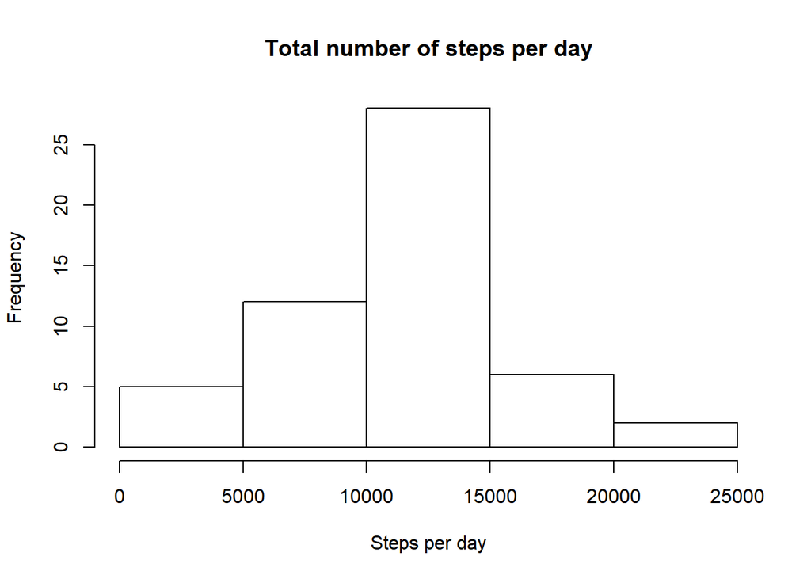

```r
stepTotal <- hist(stepDay$steps, main = "Total number of steps per day", xlab = "Steps per day")
```

The following are the mean and the median of the total number of steps taken per day:

```r
stepDayMean <- mean(stepDay$steps)
stepDayMean
```

```
## [1] 10766.19
```

```r
stepDayMedian <- median(stepDay$steps)
stepDayMedian
```

```
## [1] 10765
```

# Part 2:

## What was the average daily activity pattern?

The average number of steps taken at each 5 minute intervals:

```r
stepInterval <- aggregate(steps ~ interval, data = activeData, mean)
```

Here is the time series plot of the steps per 5 minute interval data:

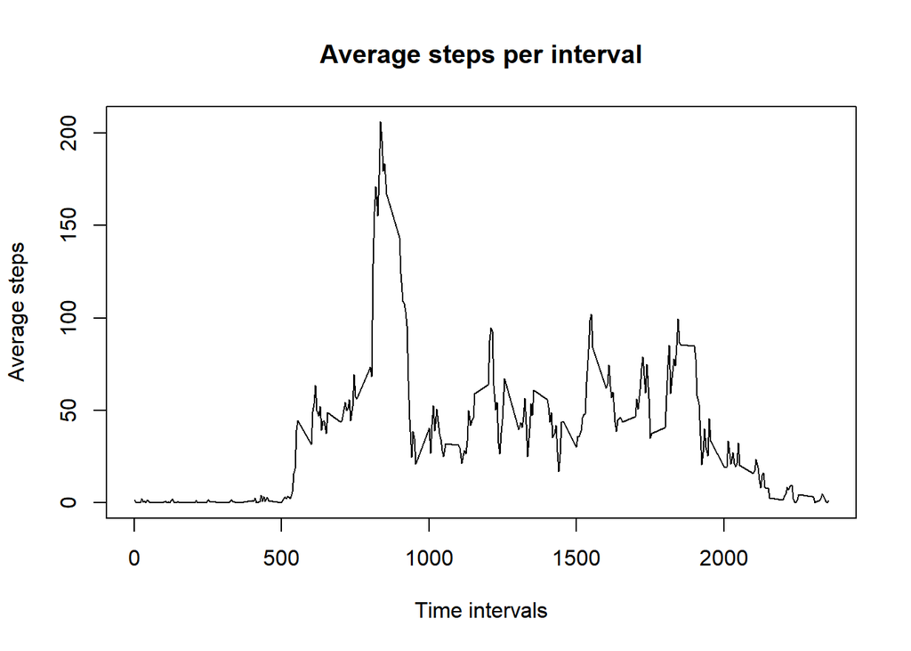

```r
plot(stepInterval$interval, stepInterval$steps, type = "l", col = 1, main = "Average steps per interval",
     xlab = "Time intervals", ylab = "Average steps")
```

```r
MaxInterval <- which.max(stepInterval$steps)
MaxInterval
```

```
## [1] 104
```

# Part 3:

## Data analysis with missing values included:

Total number of missing values in the dataset:

```r
sum(is.na(activeData))
```

```
## [1] 2304
```

There are 2304 missing values in the entire data set.

In order to fill in the issing values in the data set, a for loop can be implemented:

```r
for(i in 1:nrow(activeData)){
    if(is.na(activeData$steps[i])){
        missValue <- stepInterval$steps[which(stepInterval$interval == activeData$interval[i])]
        activeData$steps[i] <- missValue
    }
}
```

Using the loop, a new data set with the missing values was created:

```r
stepDayNA <- aggregate(steps ~ date, activeData, sum)
```

Here is the histogram of the new data set with the missing values:

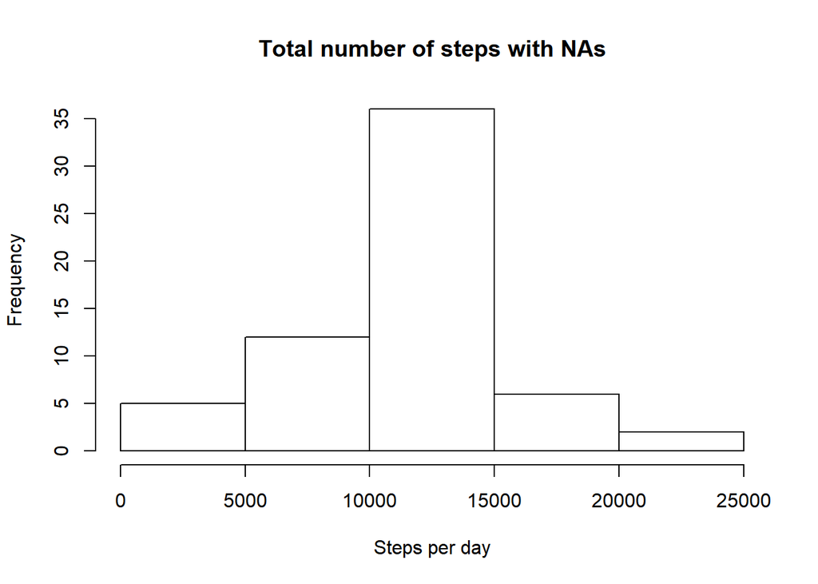

```r
hist(stepDayNA$steps, main = "Total number of steps with NAs", xlab = "Steps per day")
```

Mean and median of the total number of steps taken each day are as followed:

```r
stepDayNAMean <- mean(stepDayNA$steps)
stepDayNAMean
```

```
## [1] 10766.19
```

```r
stepDayNAMedian <- median(stepDayNA$steps)
stepDayNAMedian
```

```
## [1] 10766.19
```

It appears that the missing values did not affect these calculations.

# Part 4:

## Were there differences in the activity patterns during weekdays and weekends?

First, a new variable is created to differentiate between weekdays and weekends within the data set:

```r
ActivePattern <- function(date_val) {
    weekday <- weekdays(as.Date(date_val, '%Y-%m-%d'))
    if  (!(weekday == 'Saturday' || weekday == 'Sunday')) {
        x <- 'Weekday'
    } else {
        x <- 'Weekend'
    }
    x
}
```

Next, this vector is converted into a factor variable:

```r
activeData$day_type <- as.factor(sapply(stepDayNA$date, ActivePattern))
```

Average number of steps per interval at each corresponding weekday is aggregated together:

```r
StepsDayNA <- aggregate(steps ~ interval+day_type, activeData, mean)
```

A plot of created to show the comparison in activity patterns between weekday and weekends:

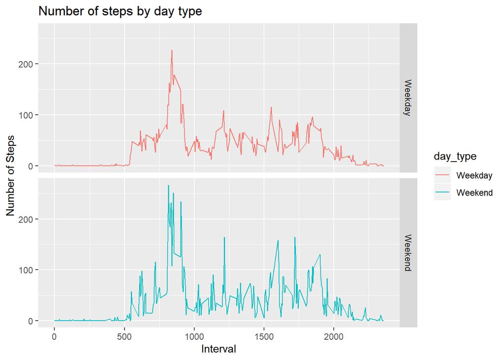

```r
library(ggplot2)
plot <- ggplot(StepsDayNA, aes(interval, steps)) +
    geom_line(stat = "identity", aes(colour = day_type)) +
    theme_gray() +
    facet_grid(day_type ~. , scales="fixed", space="fixed") +
    labs(x="Interval", y="Number of Steps", title = "Number of steps by day type")

print(plot)
```